# Mixed Effects Model Analysis

2023-08-21

### Introduction

In this document, we will analyze the behavior of mixed effects models using the lme4 library in R. Each section will focus on specific tasks related to mixed effects models, such as model fitting, hypothesis testing, and exploring influential points. Interpretation of function outputs and results will be provided through comments in the code.

```r
# Load the lme4 library
suppressPackageStartupMessages({library(lme4)})
```

### Data Loading

Let’s start by loading the dataset using the read.csv() function. The dataset contains information about politeness data.

```r
# Read in the dataset
politeness <- read.csv("http://www.bodowinter.com/tutorial/politeness_data.csv")
```

### Exploratory Data Analysis

Before diving into model analysis, let’s perform some exploratory data analysis to understand the structure of the dataset.

```r
# Display column names
print(paste0("Colnames:", colnames(politeness)))
```

```
## [1] "Colnames:subject"   "Colnames:gender"    "Colnames:scenario"
## [4] "Colnames:attitude"  "Colnames:frequency"
```

```r
# Display summary of data
print(str(politeness))
```

```
## 'data.frame':    84 obs. of  5 variables:
##  $ subject  : chr  "F1" "F1" "F1" "F1" ...
##  $ gender   : chr  "F" "F" "F" "F" ...
##  $ scenario : int  1 1 2 2 3 3 4 4 5 5 ...
##  $ attitude : chr  "pol" "inf" "pol" "inf" ...
##  $ frequency: num  213 204 285 260 204 ...
## NULL
```

```r
print(summary(politeness))
```

```
##    subject             gender             scenario   attitude
##  Length:84          Length:84          Min.   :1   Length:84
##  Class :character   Class :character   1st Qu.:2   Class :character
##  Mode  :character   Mode  :character   Median :4   Mode  :character
##                                        Mean   :4
##                                        3rd Qu.:6
##                                        Max.   :7
##
##    frequency
##  Min.   : 82.2
##  1st Qu.:131.6
##  Median :203.9
##  Mean   :193.6
##  3rd Qu.:248.6
##  Max.   :306.8
##  NA's   :1
```

### Missing Data Handling

We’ll address missing values in the dataset using various methods.

```r
# Check for missing values and their locations
which(is.na(politeness$frequency))
```

```
## [1] 39
```

```r
# Alternative method to check for missing values
which(!complete.cases(politeness))
```

```
## [1] 39
```

### Relationship Visualization

To explore relationships, we’ll create a boxplot to visualize the relationship between frequency, attitude, and gender.

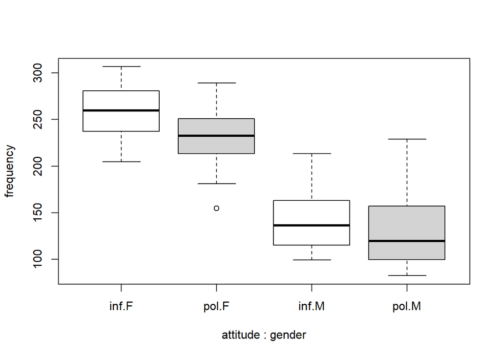

```r
# Visualize the relationship using a boxplot
boxplot(frequency ~ attitude * gender, col = c('white', 'lightgray'), data = politeness)
```

### Fitting Mixed Effects Models

We’ll fit mixed effects models to analyze the relationship between variables.

#### Model 1: Random Effects

Fitting a mixed effects model with random effects for subjects and scenarios.

```r
# Fit a mixed effects model with random effects
lmm1 <- lmer(frequency ~ attitude + (1|subject) + (1|scenario),
             data = politeness)
summary(lmm1)
```

```
## Linear mixed model fit by REML ['lmerMod']
## Formula: frequency ~ attitude + (1 | subject) + (1 | scenario)
##    Data: politeness
##
## REML criterion at convergence: 793.5
##
## Scaled residuals:
##     Min      1Q  Median      3Q     Max
## -2.2006 -0.5817 -0.0639  0.5625  3.4385
##
## Random effects:
##  Groups   Name        Variance Std.Dev.
##  scenario (Intercept)  219     14.80
##  subject  (Intercept) 4015     63.36
##  Residual              646     25.42
## Number of obs: 83, groups:  scenario, 7; subject, 6
##
## Fixed effects:
##             Estimate Std. Error t value
## (Intercept)  202.588     26.754   7.572
## attitudepol  -19.695      5.585  -3.527
##
## Correlation of Fixed Effects:
##             (Intr)
## attitudepol -0.103
```

#### Model 2: Including Gender

Fitting a mixed effects model including the gender variable.

```r
# Fit a mixed effects model with gender and random effects
lmm2 <- lmer(frequency ~ attitude + gender + (1|subject) + (1|scenario),
             data = politeness)
summary(lmm2)
```

```
## Linear mixed model fit by REML ['lmerMod']
## Formula: frequency ~ attitude + gender + (1 | subject) + (1 | scenario)
##    Data: politeness
##
## REML criterion at convergence: 775.5
##
## Scaled residuals:
##     Min      1Q  Median      3Q     Max
## -2.2591 -0.6236 -0.0772  0.5388  3.4795
##
## Random effects:
##  Groups   Name        Variance Std.Dev.
##  scenario (Intercept) 219.5    14.81
##  subject  (Intercept) 615.6    24.81
##  Residual             645.9    25.41
## Number of obs: 83, groups:  scenario, 7; subject, 6
##
## Fixed effects:
##             Estimate Std. Error t value
## (Intercept)  256.846     16.116  15.938
## attitudepol  -19.721      5.584  -3.532
## genderM     -108.516     21.013  -5.164
##
## Correlation of Fixed Effects:
##             (Intr) atttdp
## attitudepol -0.173
## genderM     -0.652  0.004
```

### Hypothesis Testing

We’ll perform hypothesis testing using the anova() function to compare models and assess significance.

```r
# Perform hypothesis testing using anova
null_lmm <- lmer(frequency ~ gender + (1|subject) + (1|scenario),
                 data = politeness, REML = F)

full_lmm <- lmer(frequency ~ attitude + gender + (1|subject) + (1|scenario),
                 data = politeness, REML = F)

anova(null_lmm, full_lmm)
```

```
## Data: politeness
## Models:
## null_lmm: frequency ~ gender + (1 | subject) + (1 | scenario)
## full_lmm: frequency ~ attitude + gender + (1 | subject) + (1 | scenario)
##          npar    AIC    BIC  logLik deviance  Chisq Df Pr(>Chisq)
## null_lmm    5 816.72 828.81 -403.36   806.72
## full_lmm    6 807.10 821.61 -397.55   795.10 11.618  1  0.0006532 ***
## ---
## Signif. codes:  0 '***' 0.001 '**' 0.01 '*' 0.05 '.' 0.1 ' ' 1
```

### Interaction Effects

We’ll investigate interaction effects and their significance using different model configurations.

```r
# Testing interaction effects using anova
full_inter <- lmer(frequency ~ attitude * gender + (1|subject) + (1|scenario),
                 data = politeness, REML = F)

full_plus <- lmer(frequency ~ attitude + gender + (1|subject) + (1|scenario),
                 data = politeness, REML = F)

full_1 <- lmer(frequency ~ 1 + (1|subject) + (1|scenario),
                 data = politeness, REML = F)

anova(full_inter, full_plus, full_1)
```

```
## Data: politeness
## Models:
## full_1: frequency ~ 1 + (1 | subject) + (1 | scenario)
## full_plus: frequency ~ attitude + gender + (1 | subject) + (1 | scenario)
## full_inter: frequency ~ attitude * gender + (1 | subject) + (1 | scenario)
##            npar    AIC    BIC  logLik deviance   Chisq Df Pr(>Chisq)
## full_1        4 826.63 836.30 -409.31   818.63
## full_plus     6 807.10 821.61 -397.55   795.10 23.5237  2  7.797e-06 ***
## full_inter    7 807.11 824.04 -396.55   793.11  1.9963  1     0.1577
## ---
## Signif. codes:  0 '***' 0.001 '**' 0.01 '*' 0.05 '.' 0.1 ' ' 1
```

### Coefficient Interpretation

Let’s explore the coefficients of the model to understand their implications.

```r
# Explore the coefficients of the model
coef(full_lmm)
```

```
## $scenario
##   (Intercept) attitudepol   genderM
## 1    243.4860   -19.72207 -108.5173
## 2    263.3592   -19.72207 -108.5173
## 3    268.1322   -19.72207 -108.5173
## 4    277.2546   -19.72207 -108.5173
## 5    254.9319   -19.72207 -108.5173
## 6    244.8015   -19.72207 -108.5173
## 7    245.9618   -19.72207 -108.5173
##
## $subject
##    (Intercept) attitudepol   genderM
## F1    243.3684   -19.72207 -108.5173
## F2    266.9442   -19.72207 -108.5173
## F3    260.2276   -19.72207 -108.5173
## M3    284.3535   -19.72207 -108.5173
## M4    262.0575   -19.72207 -108.5173
## M7    224.1293   -19.72207 -108.5173
##
## attr(,"class")
## [1] "coef.mer"
```

### Different Slopes Model

We’ll analyze a model with different slopes to account for individual variability.

```r
# Fit a model with different slopes
lmm3 <- lmer(frequency ~ attitude + gender + (1+attitude|subject) + (1+attitude|scenario),
             data = politeness, REML = F)
```

```
## boundary (singular) fit: see help('isSingular')
```

```r
coef(lmm3)
```

```
## $scenario
##   (Intercept) attitudepol   genderM
## 1    245.2630   -20.43990 -110.8062
## 2    263.3044   -15.94550 -110.8062
## 3    269.1439   -20.63124 -110.8062
## 4    276.8329   -16.30057 -110.8062
## 5    256.0602   -19.40628 -110.8062
## 6    246.8625   -21.94848 -110.8062
## 7    248.4714   -23.55653 -110.8062
##
## $subject
##    (Intercept) attitudepol   genderM
## F1    243.8065   -20.68446 -110.8062
## F2    266.7314   -19.16924 -110.8062
## F3    260.1482   -19.60436 -110.8062
## M3    285.6972   -17.91570 -110.8062
## M4    264.2019   -19.33643 -110.8062
## M7    227.3618   -21.77138 -110.8062
##
## attr(,"class")
## [1] "coef.mer"
```

### Influential Points

```r
# Identify influential points using a loop
all.res = numeric(nrow(politeness))
for (i in 1:nrow(politeness)) {
  myfullmodel = lmer(frequency ~ attitude + (1+attitude|subject), politeness[-i,])
  all.res[i] = fixef(myfullmodel)[2]
}
```

[output not shown]

[output cut: 29 more lines]

[output not shown]

### Conclusion

In this analysis, we delved into mixed effects model analysis using the `lme4` library in R. We covered data loading, exploratory data analysis, missing data handling, model fitting, hypothesis testing, interaction effects, coefficient interpretation, and the identification of influential points. Through these sections, we demonstrated the process of fitting and interpreting mixed effects models for real-world data analysis.